# **【APLM:assignment1031】**

**$\mathcal{YiHsin}\;\mathcal{Lu}$**

# **C.**

The attached data `iqsize.txt` including four variables performance IQ scores PIQ, brain size from MRI scans Size (count/10,000), height Height (inches), and weight (pounds) for n=38 college students. Analyze the data and make a summary.In addition, check whether the mentioned physical information affect IQ score performance.

## **【Linear Model】**

### $y_i=\beta_0+\beta_1x_{i1}+\beta_2x_{i2}+\beta_3x_{i3}+\epsilon_i\;,\;\forall\; i=1,\cdots,38$

- $\large{y_i}$: PIQ
- $\large{x_{i1}}$: Brain
- $\large{x_{i2}}$: Height
- $\large{x_{i3}}$: Weight

| PIQ | Brain | Height | Weight |
| --- | --- | --- | --- |
| 124 | 81.69 | 64.5 | 118 |
| 150 | 103.84 | 73.3 | 143 |
| 128 | 96.54 | 68.8 | 172 |
| 134 | 95.15 | 65.0 | 147 |
| 110 | 92.88 | 69.0 | 146 |
| 131 | 99.13 | 64.5 | 138 |
| 98 | 85.43 | 66.0 | 175 |
| 84 | 90.49 | 66.3 | 134 |
| 147 | 95.55 | 68.8 | 172 |
| 124 | 83.39 | 64.5 | 118 |

[output cut: 28 more lines]

```r
summary(lm_iq)
```

```
##
## Call:
## lm(formula = PIQ ~ ., data = iq)
##
## Residuals:
##    Min     1Q Median     3Q    Max
## -32.74 -12.09  -3.84  14.17  51.69
##
## Coefficients:
##               Estimate Std. Error t value Pr(>|t|)
## (Intercept)  1.114e+02  6.297e+01   1.768 0.085979 .
## Brain        2.060e+00  5.634e-01   3.657 0.000856 ***
## Height      -2.732e+00  1.229e+00  -2.222 0.033034 *
## Weight       5.599e-04  1.971e-01   0.003 0.997750
## ---
## Signif. codes:  0 '***' 0.001 '**' 0.01 '*' 0.05 '.' 0.1 ' ' 1
##
## Residual standard error: 19.79 on 34 degrees of freedom
## Multiple R-squared:  0.2949, Adjusted R-squared:  0.2327
## F-statistic: 4.741 on 3 and 34 DF,  p-value: 0.007215
```

## **【Pairs Plot】**

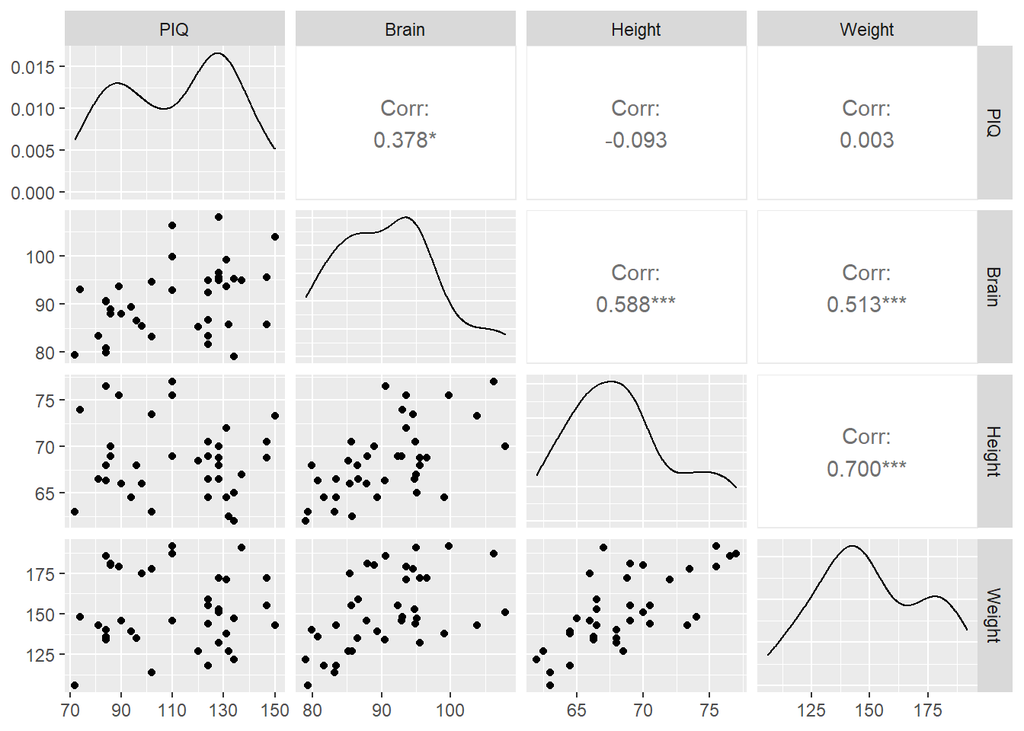

## **【T-test】**

### **1. $\beta_1 = \cfrac{Y-\hat{\beta_0}-\hat{\beta_2}X_2-\hat{\beta_3}X_3}{X_1}$**

- $\Large{H_0:\bar{\beta_1}=0}$
- $\Large{H_1:\bar{\beta_1}\neq0}$

```
##
##  One Sample t-test
##
## data:  beta1/x1
## t = 58.641, df = 37, p-value < 2.2e-16
## alternative hypothesis: true mean is not equal to 0
## 95 percent confidence interval:
##  1.989158 2.131538
## sample estimates:
## mean of x
##  2.060348
```

### **2. $\beta_2 = \cfrac{Y-\hat{\beta_0}-\hat{\beta_1}X_1-\hat{\beta_3}X_3}{X_2}$**

- $\Large{H_0:\bar{\beta_2}=0}$
- $\Large{H_1:\bar{\beta_2}\neq0}$

```
##
##  One Sample t-test
##
## data:  beta2/x2
## t = -60.095, df = 37, p-value < 2.2e-16
## alternative hypothesis: true mean is not equal to 0
## 95 percent confidence interval:
##  -2.824115 -2.639890
## sample estimates:
## mean of x
## -2.732002
```

### **3. $\beta_3 = \cfrac{Y-\hat{\beta_0}-\hat{\beta_1}X_1-\hat{\beta_2}X_2}{X_3}$**

- $\Large{H_0:\bar{\beta_3}=0}$
- $\Large{H_1:\bar{\beta_3}\neq0}$

```
##
##  One Sample t-test
##
## data:  beta3/x3
## t = 0.013417, df = 37, p-value = 0.9894
## alternative hypothesis: true mean is not equal to 0
## 95 percent confidence interval:
##  -0.04410345  0.04469141
## sample estimates:
##    mean of x
## 0.0002939823
```